# Text Classification on Consumer Reviews

## Navankur Verma - navankurverma@gmail.com

### 2nd May 2020

### Contents:

i) Scrapping

ii) Pre-Processing

iii) Cross-Evaluation

Libraries used:

```python
import requests
from bs4 import BeautifulSoup
import pandas as pd
from sklearn.model_selection import train_test_split, cross_validate,cross_val_score, RepeatedKFold
from sklearn.metrics import *
from sklearn.ensemble import RandomForestClassifier
from sklearn.naive_bayes import MultinomialNB
from sklearn.linear_model import LogisticRegression
import nltk
from sklearn.feature_extraction.text import CountVectorizer, TfidfVectorizer
import matplotlib.pyplot as plt
%matplotlib inline
```

### Scrapping:

```python
page = requests.get("http://mlg.ucd.ie/modules/yalp/") #pull html from the source of given url
soup = BeautifulSoup(page.content, 'html.parser') #parse the html to generate an html tag wise iterable BeautifulSoup object
[type(item) for item in list(soup.children)]
```

```
[bs4.element.Doctype,
 bs4.element.NavigableString,
 bs4.element.Tag,
 bs4.element.NavigableString]
```

```python
html = list(soup.children)[2] #need to extract info from html body which is in 3rd place (2nd index)
[type(item) for item in list(html.children)] #now we have the html 'head' and 'body' at 2nd & 4th position
```

```
[bs4.element.NavigableString,
 bs4.element.Tag,
 bs4.element.NavigableString,
 bs4.element.Tag,
 bs4.element.NavigableString]
```

```python
categories = []
businesses = []
urls = []
for match in html.find_all("h4"): #searching for 'h4' tags that contains categories and their respective links
    urls.append('http://mlg.ucd.ie/modules/yalp/'+
                list(match.children)[0]['href'])#each 'h4' tag has its link in 'href' tag of first element
    text = match.get_text() #extracting text of each 'h4' tag
    #splitting first with ':' to get 2nd element and then splitting it with '\xa0' (equivalent to &nbsp in html)
    text = text.split(':')[1].split('\xa0')
    #resultant element will have category name at 1st place:(starting index = 1 as first char is space)
    categories.append(text[0][1:])
    #3rd element can be split further and 1st element will be counts of businesses (starting index = 1 as first char is bracket):
    businesses.append(text[2].split()[0][1:])
list(zip(urls,categories, businesses)) #zip combines each list element-wise into list of 3-tuples
```

```
[('http://mlg.ucd.ie/modules/yalp/automotive_list.html', 'Automotive', '132'),
 ('http://mlg.ucd.ie/modules/yalp/cafes_list.html', 'Cafes', '96'),
 ('http://mlg.ucd.ie/modules/yalp/fashion_list.html', 'Fashion', '159'),
 ('http://mlg.ucd.ie/modules/yalp/gym_list.html', 'Gym', '122'),
 ('http://mlg.ucd.ie/modules/yalp/hair_salons_list.html',
  'Hair and Salons',
  '143'),
 ('http://mlg.ucd.ie/modules/yalp/hotels_list.html', 'Hotels', '113'),
 ('http://mlg.ucd.ie/modules/yalp/restaurants_list.html',
  'Restaurants',
  '100')]
```

Instead, we can also search directly in whole scrapped page, sometimes it can be useful if the webpage is written in 'good-html'. Otherwise, we should always drill down element by element until we get the required tag having information we need.

```python
categories = []
businesses = []
urls = []
for match in soup.find_all("h4"): #searching full page for 'h4' tag, which is used only for categories and urls in this webpage
    urls.append('http://mlg.ucd.ie/modules/yalp/'+
                list(match.children)[0]['href']) #each 'h4' tag has its link in 'href' tag of first element
    text = match.get_text() #extracting text of each 'h4' tag
    #splitting first with ':' to get 2nd element and then splitting it with '\xa0' (equivalent to &nbsp in html):
    text = text.split(':')[1].split('\xa0')
    #resultant element will have category name at 1st place (starting index = 1 as first char is space):
    categories.append(text[0][1:])
    #3rd element can be split further and 1st element will be counts of businesses (starting index = 1 as first char is bracket):
    businesses.append(text[2].split()[0][1:])
list(zip(urls,categories, businesses)) #zip combines each list element-wise into list of 3-tuples
```

```
[('http://mlg.ucd.ie/modules/yalp/automotive_list.html', 'Automotive', '132'),
 ('http://mlg.ucd.ie/modules/yalp/cafes_list.html', 'Cafes', '96'),
 ('http://mlg.ucd.ie/modules/yalp/fashion_list.html', 'Fashion', '159'),
 ('http://mlg.ucd.ie/modules/yalp/gym_list.html', 'Gym', '122'),
 ('http://mlg.ucd.ie/modules/yalp/hair_salons_list.html',
  'Hair and Salons',
  '143'),
 ('http://mlg.ucd.ie/modules/yalp/hotels_list.html', 'Hotels', '113'),
 ('http://mlg.ucd.ie/modules/yalp/restaurants_list.html',
  'Restaurants',
  '100')]
```

```python
try:
    reviews = pd.read_csv("all_reviews.csv", index_col= 0)
except FileNotFoundError: #if file not found then perform the scrapping & store the file:

    #there are three levels to get to the reviews page of a business of a category:
    #Parent page -> Category page -> Business page with all reviews
    #already extracted urls of each category, now using three nested for loops:
    #for each category
    #   for each business in that category
    #      for each review of that business

    all_reviews = []
    for category in list(zip(urls, categories, businesses)):
        category_page = requests.get(category[0])
        if category_page.status_code == 200: #check if link request completed successfully
            soup1 = BeautifulSoup(category_page.content, 'html.parser')
            for match in soup1.find_all("h5"): #extracting 'h5' tag as it contains business names and their links
                business_name = list(match.children)[1].get_text() #each 'h5' has 'a' tag with name of business as text
                # and href of 'a' tag contains the link to reviews of that business:
                bus_review = requests.get('http://mlg.ucd.ie/modules/yalp/'+list(match.children)[1]['href'])
                if bus_review.status_code == 200: #check if link request completed successfully
                    soup2 = BeautifulSoup(bus_review.content, 'html.parser')
                    #iterating over each review which is in a 'div' tag of class 'review':
                    for reviews in soup2.find_all('div',class_ = 'review'):
                        review = {} #blank dictionary to be appended in final list 'all_reviews'
                        #extracting rating from the 2nd 'p' tag:
                        review['rating'] = list(list(reviews.children)[2].children)[0]['alt']
                        #extracting review text from 3rd 'p' tag:
                        review['text'] = list(reviews.children)[3].get_text()
                        #storing the Business Category:
                        review['category'] = category[1]
                        #storing the name of Business:
                        review['business_name'] = business_name
                        all_reviews.append(review) #appending each review to form a list of dictionary
                else:
                    print('Not able to acces link:','http://mlg.ucd.ie/modules/yalp/'+list(match.children)[1]['href'])
        else:
            print('Not able to acces link:',category[0])
    reviews = pd.DataFrame(all_reviews) #converting list of dictionary into pandas DataFrame
    reviews.to_csv("all_reviews.csv") #storing the csv file
```

```python
reviews.head()
```

|  | rating | text | category | business_name |
| --- | --- | --- | --- | --- |
| 0 | 1-star | The man that was working tonight (8-12-17) was... | Automotive | 7-Eleven |
| 1 | 1-star | Chris is a very rude person. Gave me an attitu... | Automotive | 7-Eleven |
| 2 | 5-star | One of my favorite gas station to stop at. The... | Automotive | 7-Eleven |
| 3 | 3-star | Oh thank Heaven for Seven Eleven! I don't know... | Automotive | 7-Eleven |
| 4 | 5-star | Five stars because of the guy who works weekda... | Automotive | 7-Eleven |

```python
reviews['rating'] = reviews['rating'].isin(["4-star","5-star"]).astype('int') #"Positive" : 1 & "Negative" : 0
```

```python
reviews.head()
```

|  | rating | text | category | business_name |
| --- | --- | --- | --- | --- |
| 0 | 0 | The man that was working tonight (8-12-17) was... | Automotive | 7-Eleven |
| 1 | 0 | Chris is a very rude person. Gave me an attitu... | Automotive | 7-Eleven |
| 2 | 1 | One of my favorite gas station to stop at. The... | Automotive | 7-Eleven |
| 3 | 0 | Oh thank Heaven for Seven Eleven! I don't know... | Automotive | 7-Eleven |
| 4 | 1 | Five stars because of the guy who works weekda... | Automotive | 7-Eleven |

```python
imbalance =pd.crosstab(index=reviews["category"],
            columns=reviews["rating"],
            margins=True)
imbalance
```

| rating category | 0 | 1 | All |
| --- | --- | --- | --- |
| Automotive | 788 | 1212 | 2000 |
| Cafes | 538 | 1462 | 2000 |
| Fashion | 795 | 1205 | 2000 |
| Gym | 701 | 1299 | 2000 |
| Hair and Salons | 442 | 1558 | 2000 |
| Hotels | 824 | 1176 | 2000 |
| Restaurants | 838 | 1162 | 2000 |
| All | 4926 | 9074 | 14000 |

Each Category has 2000 reviews in total, but there are more number of "Positive" reviews in each category than "Negative" ones.

```python
imbalance.div(imbalance.All, axis = 'rows')[[0,1]]*100
```

| rating category | 0 | 1 |
| --- | --- | --- |
| Automotive | 39.400000 | 60.600000 |
| Cafes | 26.900000 | 73.100000 |
| Fashion | 39.750000 | 60.250000 |
| Gym | 35.050000 | 64.950000 |
| Hair and Salons | 22.100000 | 77.900000 |
| Hotels | 41.200000 | 58.800000 |
| Restaurants | 41.900000 | 58.100000 |
| All | 35.185714 | 64.814286 |

It would be better two train classification models on categories which have balanced classes in target variables. There is no perfectly balanced category available having 50% observations of each target class label. So choosing those categories which are more balanced than rest:  
A. Restaurants  
B. Hotels  
C. Fashion

```python
restaurants = reviews.loc[reviews.category == 'Restaurants', ['rating','text']]
hotels = reviews.loc[reviews.category == 'Hotels', ['rating','text'] ]
fashion = reviews.loc[reviews.category == 'Fashion', ['rating','text'] ]
```

```python
restaurants.head()
```

|  | rating | text |
| --- | --- | --- |
| 12000 | 0 | My husband and I had a rare afternoon off so w... |
| 12001 | 1 | For years I thought this was only a wine store... |
| 12002 | 1 | This place is so charming! I went with my husb... |
| 12003 | 1 | We have been wanting to try this place for a c... |
| 12004 | 0 | Decor looks ok but layout is too busy. Difficu... |

```python
hotels.head()
```

|  | rating | text |
| --- | --- | --- |
| 10000 | 1 | Melissa took us on a tour of Asia in the space... |
| 10001 | 1 | With a group of seven of us visiting Montreal ... |
| 10002 | 1 | Melissa is a gem! My fiancé found her tour on ... |
| 10003 | 1 | A perfect day in Montreal! Melissa outfitted u... |
| 10004 | 1 | I had a really great food truck tour with Meli... |

```python
fashion.head()
```

|  | rating | text |
| --- | --- | --- |
| 4000 | 1 | Looking for the best tactical supplies? Look n... |
| 4001 | 0 | Stood in line like an idiot for 5 minutes to p... |
| 4002 | 1 | Another great store with quality Equipment. Th... |
| 4003 | 1 | The Problem with this store is not that they h... |
| 4004 | 1 | Great place! We went in at almost closing time... |

### Preprocessing

Back to top

Tokeninzing the words of each document (review) has many aspects majorly of the form:

1. choosing the type of tokenizer - Simple count based or based on weights using Term Frequency-Inverse Document Frequency.
2. stemming of the words - converting words into their root form
3. minimum document frequency - selecting those words which occur at least in some number of documents.
4. stop words - remvoing the common words

```python
def lemma_tokenizer(text):
    # use the standard scikit-learn tokenizer first
    standard_tokenizer = CountVectorizer().build_tokenizer()
    tokens = standard_tokenizer(text)
    # then use NLTK to perform lemmatisation on each token
    lemmatizer = nltk.stem.WordNetLemmatizer()
    lemma_tokens = []
    for token in tokens:
        lemma_tokens.append( lemmatizer.lemmatize(token,'v') )
    return lemma_tokens
vectorizer = TfidfVectorizer(min_df=5, stop_words=None, tokenizer=lemma_tokenizer)
```

- To reduce the number of tokens (words), here NLTK lemmatizer with words converted to their basic form of verbs, will be implemented.
- Although after setting Minimum number of document frequency higher, number of tokens (dimension) gets reduced but there was a drop in classification accuracy also. Setting it to 5 gives better result because more such words are incuded as variables in models, which helps to classify a review into one of the types perfectly (either positive or negative).

Separating target variable and applying tokenizer created above to all reviews of each category:

```python
text = hotels.text
hotels_target = hotels.rating
hotels_subMat = vectorizer.fit_transform(text)
print(hotels_subMat.shape)
```

```
(2000, 2831)
```

```python
text = restaurants.text
restaurant_target = restaurants.rating
restaurant_subMat = vectorizer.fit_transform(text)
print(restaurant_subMat.shape)
```

```
(2000, 2567)
```

```python
text = fashion.text
fashion_target = fashion.rating
fashion_subMat = vectorizer.fit_transform(text)
print(fashion_subMat.shape)
```

```
(2000, 2370)
```

```python
classes = [["Hotel",hotels_subMat,hotels_target],
           ["Restaurant",restaurant_subMat,restaurant_target],
           ["Fashion",fashion_subMat,fashion_target]]
```

### Model Selection and Evaluation:

Running all three (Naive Bayes, Random Forest & Logistic Regression) models in repeated k-fold setting for each category and selecting the best suited model based on balanced accuracy score for building a classifier for that category.  
As observed, classes in each category are imbalanced, so a simple accuracy will not be a true criteria for evaluation, instead we can use balanced accuracy as it normalizes true positive and true negative predictions by the number of positive and negative samples, respectively, and divides their sum by two.

```python
seed = 19200115 #to reproduce same results and each model gets evaluated on same split.
acc= [] #list to store category and its accuracy scores from each model
rkf = RepeatedKFold(n_splits=5, n_repeats=10, random_state=seed) #10 repeats with 5 chunks of split data
models = [("Naive_Bayes", MultinomialNB(alpha=0.1)), #Using Multinomial Naive Bayes with smoothing of 0.1
          ("Random_Forest",RandomForestClassifier(n_estimators=500, ccp_alpha=0.0001)), #RandomForest with 500 trees and complexity parameter of 0.0001
          ("Logistic_Regression",LogisticRegression())] #Using default Logistic regression with BFGS optimizer
for data in classes: #looping over each category
    racc = pd.DataFrame() #dataframe to store each models accuracy
    for model in models: #looping over each model
        repeated_acc_scores = cross_val_score(model[1], #Model object at 2nd position of tuple
                                              data[1], #Sub-matrix as training data
                                              data[2], #Target variable
                                              cv=rkf, #repeated K-fold with seed, so that each model gets evaluated on equivalent data
                                              scoring="balanced_accuracy") #extracting the balanced accuracy in each cycle
        racc[model[0]] = repeated_acc_scores #storing accuracies in column named on the model it came from
    print('For category:',data[0],'\nBest model:',
    racc.mean().sort_values(ascending=False).index[0],'\nWith avg repeated k-fold balanced accuracy:',
    racc.mean().sort_values(ascending=False)[0],'\n')
    acc.append([data[0],racc]) #appending accuracy scores of each category
```

```
For category: Hotel
Best model: Naive_Bayes
With avg repeated k-fold balanced accuracy: 0.8935507462096467

For category: Restaurant
Best model: Logistic_Regression
With avg repeated k-fold balanced accuracy: 0.8652108683531705

For category: Fashion
Best model: Naive_Bayes
With avg repeated k-fold balanced accuracy: 0.8656712549524541
```

#### Visualizing the accuracies:

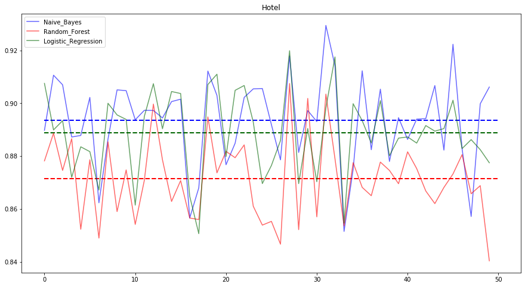

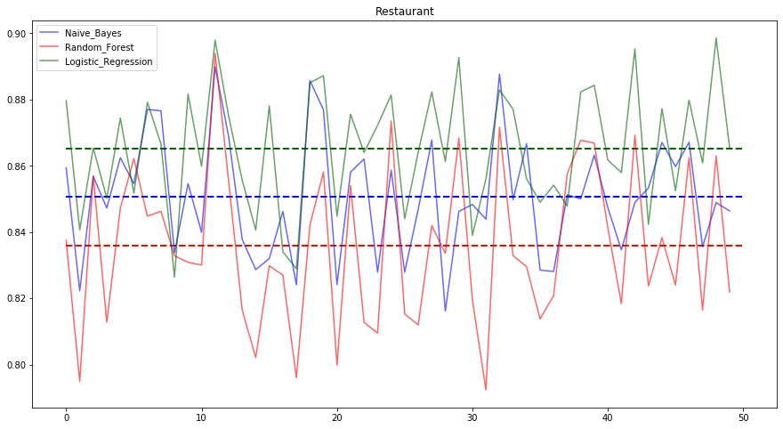

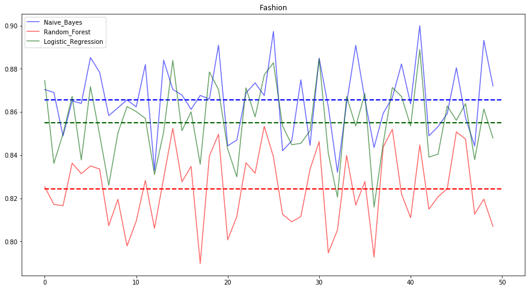

```python
for category, accu in acc:
    accu.plot(color=['blue', 'red','darkgreen'], figsize = (15,8), alpha = 0.6, title = category);
    plt.hlines(y=accu.Naive_Bayes.mean(), xmin=0, xmax=len(accu), colors='blue', linestyles='--', lw=2);
    plt.hlines(y=accu.Random_Forest.mean(), xmin=0, xmax=len(accu), colors='red', linestyles='--', lw=2);
    plt.hlines(y=accu.Logistic_Regression.mean(), xmin=0, xmax=len(accu), colors='darkgreen', linestyles='--', lw=2);
```

For Hotel & Fashion category, Naive Bayes classifier comes out to be best and for Restaurant category, Logistic Regression classifier. Implementing a simple hold-out cross validation with training-test (80%-20%) to evaluate each models general capability of classification:

#### Model Based on Hotels Category:

```python
data_train, data_test, target_train, target_test = train_test_split(hotels_subMat, hotels_target, test_size=0.2, random_state =seed)
hotel_train = MultinomialNB(alpha=0.1)
hotel_train.fit(data_train, target_train)
hotel_pred = hotel_train.predict(data_test)
print("Category: Hotels\n",classification_report(target_test, hotel_pred, target_names=["Negative","Positive"]))
print("Balanced Accuracy:",balanced_accuracy_score(target_test, hotel_pred))
```

```
Category: Hotels
               precision    recall  f1-score   support

    Negative       0.92      0.83      0.87       158
    Positive       0.89      0.95      0.92       242

    accuracy                           0.90       400
   macro avg       0.91      0.89      0.90       400
weighted avg       0.90      0.90      0.90       400

Balanced Accuracy: 0.8897635735955645
```

#### Model Based on Restaurant Category:

```python
data_train, data_test, target_train, target_test = train_test_split(restaurant_subMat, restaurant_target, test_size=0.2, random_state =seed)
restaurant_train = LogisticRegression()
restaurant_train.fit(data_train, target_train)
restaurant_pred = restaurant_train.predict(data_test)
print("Category: Restaurant\n",classification_report(target_test, restaurant_pred, target_names=["Negative","Positive"]))
print("Balanced Accuracy:",balanced_accuracy_score(target_test, restaurant_pred))
```

```
Category: Restaurant
               precision    recall  f1-score   support

    Negative       0.84      0.87      0.85       157
    Positive       0.91      0.89      0.90       243

    accuracy                           0.88       400
   macro avg       0.88      0.88      0.88       400
weighted avg       0.88      0.88      0.88       400

Balanced Accuracy: 0.879623076721449
```

#### Model Based on Fashion Category:

```python
data_train, data_test, target_train, target_test = train_test_split(fashion_subMat, fashion_target, test_size=0.2, random_state =seed)
fashion_train = MultinomialNB(alpha=0.1)
fashion_train.fit(data_train, target_train)
fashion_pred = fashion_train.predict(data_test)
print("Category: Fashion\n",classification_report(target_test, fashion_pred, target_names=["Negative","Positive"]))
print("Balanced Accuracy:",balanced_accuracy_score(target_test, fashion_pred))
```

```
Category: Fashion
               precision    recall  f1-score   support

    Negative       0.88      0.81      0.85       159
    Positive       0.88      0.93      0.91       241

    accuracy                           0.88       400
   macro avg       0.88      0.87      0.88       400
weighted avg       0.88      0.88      0.88       400

Balanced Accuracy: 0.8703906678149221
```

In evaluation of each category, Recall of a Positive Review is higher than a Negative Review, this can be accounted for the fact of having imbalanced data. But still the overall accuracy and balanced accuracy are more than 87%, which suggests that model is able to predict the type of review quite well.  
Accuracy & Balanced Accuracy on Hotels Category: 90% & 88.9%  
Accuracy & Balanced Accuracy on Restaurant Category: 88% & 87.9%  
Accuracy & Balanced Accuracy on Fashion Category: 88% & 87.0%

### Cross-Evaluation:

Back to top

To evaluate the performance of each selected classifier, we can test it with data of different category. First, creating a corresponding selected classifier on full data of each category and then applying same model for predictions on other two categories.  
Here it should be noted that testing data sub matrix should be built on the same fitted submatrix built using training dataset.

#### Model Based on Hotels category: (Naive Bayes)

```python
text = hotels.text
hotels_target = hotels.rating
hotels_subMat = vectorizer.fit_transform(text) #creating training sub matrix
print(hotels_subMat.shape)
```

```
(2000, 2831)
```

```python
test  = pd.concat([restaurants, fashion]) #joining other two categories
hotels_test = vectorizer.transform(test.text) #transforming using the already fitted vectorizer
print(hotels_test.shape)
```

```
(4000, 2831)
```

```python
hotel_train = MultinomialNB(alpha=0.1) #fitting Naive Bayes using hotels category data
hotel_train.fit(hotels_subMat, hotels_target)
hotel_pred = hotel_train.predict(hotels_test) #predicting for other two categories
print(classification_report(test.rating, hotel_pred, target_names=["Negative","Positive"]))
print("Balanced Accuracy:",balanced_accuracy_score(test.rating, hotel_pred))
```

```
              precision    recall  f1-score   support

    Negative       0.89      0.67      0.77      1633
    Positive       0.81      0.94      0.87      2367

    accuracy                           0.83      4000
   macro avg       0.85      0.81      0.82      4000
weighted avg       0.84      0.83      0.83      4000

Balanced Accuracy: 0.8069666321804377
```

As compared to predictions done for same category on which model was trained, Accuracy & Balanced Accuracy reduced from 90% & 88.9% to 83% & 80%, respectively.  
Recall for Negative reviews reduced dramatically, from 83% to 67%, conveying that model based on Hotel Category was not able to predict the Negative reviews of Restaurant and Fashion categories well enough. Whereas Recall for Positive reviews almost remained same from being at 95% to 94%.  
This suggests that Positive reviews of Hotels Category tend to be quite similar but there is big difference in Negative reveiws of Restaurant & fashion category.

```python
test  = restaurants #checking on individual category
hotels_test = vectorizer.transform(test.text) #transforming using the already fitted vectorizer
hotel_pred = hotel_train.predict(hotels_test) #predicting for other two categories
print(classification_report(test.rating, hotel_pred, target_names=["Negative","Positive"]))
```

```
              precision    recall  f1-score   support

    Negative       0.91      0.58      0.71       838
    Positive       0.76      0.96      0.85      1162

    accuracy                           0.80      2000
   macro avg       0.84      0.77      0.78      2000
weighted avg       0.83      0.80      0.79      2000
```

```python
test  = fashion #checking on individual category
hotels_test = vectorizer.transform(test.text) #transforming using the already fitted vectorizer
hotel_pred = hotel_train.predict(hotels_test) #predicting for other two categories
print(classification_report(test.rating, hotel_pred, target_names=["Negative","Positive"]))
```

```
              precision    recall  f1-score   support

    Negative       0.87      0.76      0.81       795
    Positive       0.85      0.93      0.89      1205

    accuracy                           0.86      2000
   macro avg       0.86      0.84      0.85      2000
weighted avg       0.86      0.86      0.86      2000
```

Above classification reports suggest that reduction in Recall of Negative reviews is more because of Restaurant category, as Recall of Negative reviews when prediction of Restaurant category based on model trained on Hotels review is as low as 58%, while it is 76% when prediction is done on Fashion category.

#### Model Based on Restaurant category: (Logistic Regression)

```python
text = restaurants.text
restaurants_target = restaurants.rating
restaurants_subMat = vectorizer.fit_transform(text) #creating training sub matrix
print(restaurants_subMat.shape)
```

```
(2000, 2567)
```

```python
test  = pd.concat([hotels, fashion]) #joining other two categories
restaurants_test = vectorizer.transform(test.text) #transforming using the already fitted vectorizer
print(restaurants_test.shape)
```

```
(4000, 2567)
```

```python
restaurants_train = LogisticRegression() #fitting Logistic Regression using Restaurant category data
restaurants_train.fit(restaurants_subMat, restaurants_target)
restaurants_pred = restaurants_train.predict(restaurants_test) #predicting for other two categories
print(classification_report(test.rating, restaurants_pred, target_names=["Negative","Positive"]))
print("Balanced Accuracy:",balanced_accuracy_score(test.rating, restaurants_pred))
```

```
              precision    recall  f1-score   support

    Negative       0.73      0.90      0.81      1619
    Positive       0.92      0.78      0.84      2381

    accuracy                           0.83      4000
   macro avg       0.83      0.84      0.83      4000
weighted avg       0.84      0.83      0.83      4000

Balanced Accuracy: 0.8384859912437329
```

As compared to predictions done for same category on which model was trained, Accuracy & Balanced Accuracy reduced from 88% & 87.9% to 83% & 83.8%, respectively.  
Recall for Positive reviews reduced by 11 percent points, from 89% to 78%, conveying that model based on Restaurant Category was not able to predict the Positive reviews of Hotels and Fashion categories well enough. Whereas Recall for Negative reviews remained same.  
This suggests that Positive reviews of Restaurant Category tend to be different while Negative reveiws are similar to those of of Hotels & Fashion category.

```python
test = hotels #checking on individual category
restaurant_test = vectorizer.transform(test.text) #transforming using the already fitted vectorizer
restaurant_pred = restaurant_train.predict(restaurant_test) #predicting for other two categories
print(classification_report(test.rating, restaurant_pred, target_names=["Negative","Positive"]))
```

```
              precision    recall  f1-score   support

    Negative       0.76      0.89      0.82       824
    Positive       0.91      0.80      0.85      1176

    accuracy                           0.84      2000
   macro avg       0.83      0.84      0.83      2000
weighted avg       0.85      0.84      0.84      2000
```

```python
test = fashion #checking on individual category
restaurant_test = vectorizer.transform(test.text) #transforming using the already fitted vectorizer
restaurant_pred = restaurant_train.predict(restaurant_test) #predicting for other two categories
print(classification_report(test.rating, restaurant_pred, target_names=["Negative","Positive"]))
```

```
              precision    recall  f1-score   support

    Negative       0.69      0.90      0.79       795
    Positive       0.92      0.74      0.82      1205

    accuracy                           0.80      2000
   macro avg       0.81      0.82      0.80      2000
weighted avg       0.83      0.80      0.81      2000
```

#### Model Based on Fashion category: (Naive Bayes)

```python
text = fashion.text
fashion_target = fashion.rating
fashion_subMat = vectorizer.fit_transform(text) #creating training sub matrix
print(fashion_subMat.shape)
```

```
(2000, 2370)
```

```python
test  = pd.concat([restaurants, hotels]) #joining other two categories
fashion_test = vectorizer.transform(test.text) #transforming using the already fitted vectorizer
print(fashion_test.shape)
```

```
(4000, 2370)
```

```python
fashion_train = MultinomialNB(alpha=0.1) #fitting Naive Bayes using Fashion category data
fashion_train.fit(fashion_subMat, fashion_target)
fashion_pred = fashion_train.predict(fashion_test) #predicting for other two categories
print(classification_report(test.rating, fashion_pred, target_names=["Negative","Positive"]))
print("Balanced Accuracy:",balanced_accuracy_score(test.rating, fashion_pred))
```

```
              precision    recall  f1-score   support

    Negative       0.90      0.72      0.80      1662
    Positive       0.83      0.94      0.88      2338

    accuracy                           0.85      4000
   macro avg       0.86      0.83      0.84      4000
weighted avg       0.86      0.85      0.85      4000

Balanced Accuracy: 0.8326076058301138
```

As compared to predictions done for same category on which model was trained, Accuracy & Balanced Accuracy reduced from 88% & 87.0% to 85% & 83.2%, respectively.  
Recall for Negative reviews reduced from 81% to 72% suggesting that model trained using Fashion category is not able to ditinguish the Negative reviews of Hotel & Restaurant category well enough. Whereas, Recall remained almost same for Positive Reviews.

```python
test  = restaurants #checking on individual category
fashion_test = vectorizer.transform(test.text) #transforming using the already fitted vectorizer
fashion_pred = fashion_train.predict(fashion_test) #predicting for other two categories
print(classification_report(test.rating, fashion_pred, target_names=["Negative","Positive"]))
```

```
              precision    recall  f1-score   support

    Negative       0.89      0.64      0.74       838
    Positive       0.78      0.94      0.85      1162

    accuracy                           0.81      2000
   macro avg       0.83      0.79      0.80      2000
weighted avg       0.83      0.81      0.81      2000
```

```python
test  = hotels #checking on individual category
fashion_test = vectorizer.transform(test.text) #transforming using the already fitted vectorizer
fashion_pred = fashion_train.predict(fashion_test) #predicting for other two categories
print(classification_report(test.rating, fashion_pred, target_names=["Negative","Positive"]))
```

```
              precision    recall  f1-score   support

    Negative       0.92      0.80      0.86       824
    Positive       0.87      0.95      0.91      1176

    accuracy                           0.89      2000
   macro avg       0.89      0.88      0.88      2000
weighted avg       0.89      0.89      0.89      2000
```

As observed from the above classification reports, reduction of overall Recall on Negative reviews is more due to Restaurant Category, as it reduces to 64% when prediction is done on Reviews of Restaurant category and remains same when prediction is done on Hotels category.